# Лабораторная работа №7

Презентация

Устинова В. В.

Российский университет дружбы народов, Москва, Россия

27 марта 2025

# Информация

## Докладчик

- Устинова Виктория Вадимовна
- студент НПИбд-01-24
- Российский университет дружбы народов

## Цель работы

Онакомление с файловой системой Linux, её структурой, именами и содержанием каталогов. Приобретение практических навыков по применению команд для работы с файлами и каталогами, по управлению процессами (и работами), по проверке использования диска и обслуживанию файловой системы.

## Копирование файлов и каталогов

Копирование файла в текущем каталоге. Скопировать файл ~/abc1 в файл april и в файл may

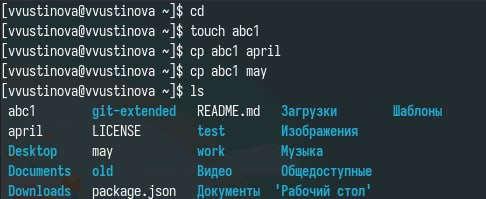

Используем команду cd и ls

## Копирование файлов и каталогов

Скопировать файлы april и may в каталог monthly и скопировать файл monthly/may в файл с именем june

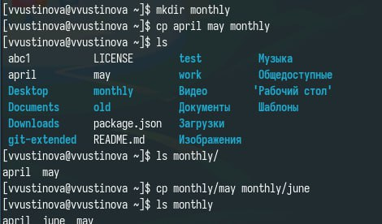

Копируем файлы

## Копирование файлов и каталогов

Скопировать каталог monthly в каталог monthly.00 и Скопировать каталог monthly.00 в каталог /tmp

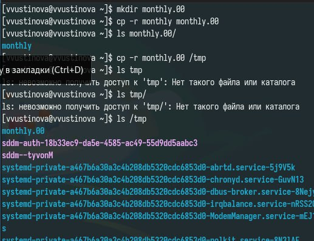

копируем и смотрим

## Перемещение и переименование файлов и каталогов

Изменить название файла april на july в домашнем каталоге и Переместить файл july в каталог monthly.00

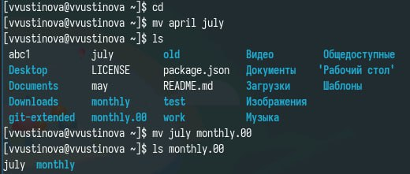

Выполняем и проверяем

## Перемещение и переименование файлов и каталогов

Переименовать каталог monthly.00 в monthly.01

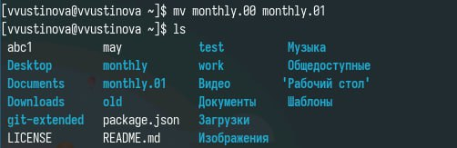

вводим команду

## Перемещение и переименование файлов и каталогов

Переместить каталог monthly.01в каталог reports и Переименовать каталог reports/monthly.01 в reports/monthly

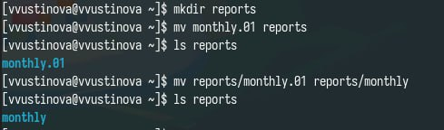

Создаем reports и перемеиновываем

## Изменение прав доступа

Требуется создать файл ~/may с правом выполнения для владельца,Требуется лишить владельца файла ~/may права на выполнение

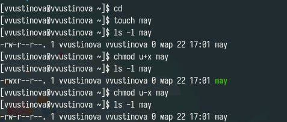

Управление доступом

## Изменение прав доступа

Требуется создать каталог monthly с запретом на чтение для членов группы и всех остальных пользователей

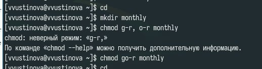

Создаем каталог и запрещаем чтение

## Изменение прав доступа

Требуется создать файл ~/abc1 с правом записи для членов группы

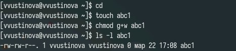

Создаем и проверяем как выполнилось

## Последовательность выполнения работы

Скопируйте файл /usr/include/sys/io.h в домашний каталог и назовите его equipment,в домашнем каталоге создайте директорию ~/ski.plases,переместите файл equipment в каталог ~/ski.plases

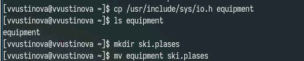

Создаем, копируем и перемещаем

## Последовательность выполнения работы

Переименуйте файл ~/ski.plases/equipment в ~/ski.plases/equiplist.Создайте в домашнем каталоге файл abc1 и скопируйте его в каталог~/ski.plases, назовите его equiplist2

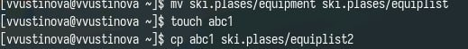

## Последовательность выполнения работы

Создайте каталог с именем equipment в каталоге ~/ski.plases.Переместите файлы ~/ski.plases/equiplist и equiplist2 в каталог~/ski.plases/equipment.Создайте и переместите каталог ~/newdir в каталог ~/ski.plases и назовите его plans

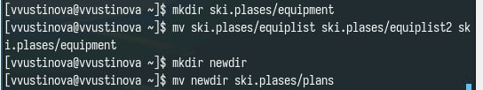

Выполняем каждое действие поочередно

## Последовательность выполнения работы

Создайте нужные файлы и дайте им выделенные права доступа

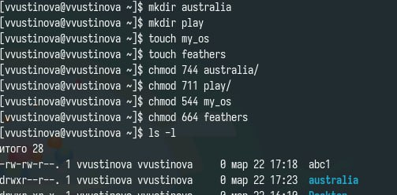

Создаем файлы и каталоги,задаем права и проверяем

## Последовательность выполнения работы

Просмотрите содержимое файла /etc/password

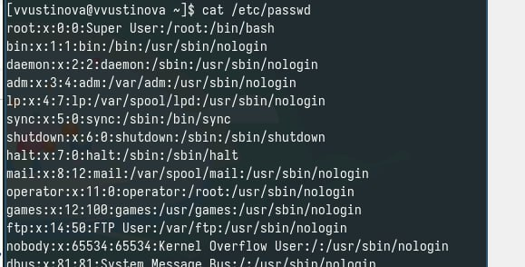

Смотрим с помощью cat

## Последовательность выполнения работы

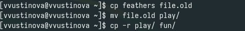

## Последовательность выполнения работы

Переместите каталог ~/fun в каталог ~/play и назовите его games.Лишите владельца файла ~/feathers права на чтение.Что произойдёт, если вы попытаетесь скопировать файл ~/feathers?

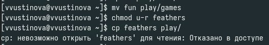

Отказано в доступе

## Последовательность выполнения работы

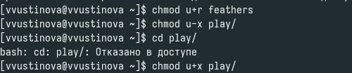

Отказано в доступе, но потом меняем право

## Последовательность выполнения работы

Прочитайте man по командам mount, fsck, mkfs, kill

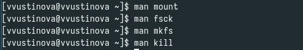

Выполнили успешно команду